# TASK 3 邻接矩阵

狗熊会

邻接矩阵是网络结构数据中的重要概念，可以反映节点之间的关系。

任务介绍：本任务主要学习邻接矩阵的概念以及如何用R语言中的igraph包生成邻接矩阵。

这个案例的学习目标包括：

1. 学习邻接矩阵的相关概念；
2. 并学习如何使用R语言生成邻接矩阵；

### 准备工作

```r
#清除工作环境
cat("\014");rm(list=ls())
```

```r
#加载相应的包,若没有,请先用 install.packages("igraph") 命令安装
library(igraph)
```

### 任务一: 学习邻接矩阵的相关概念，并利用R语言生成网络的邻接矩阵

网络结构数据中还有一个重要概念是邻接矩阵。用一个二维数组存放顶点间关系(边或弧)的数据，这个二维数组称为**邻接矩阵（Adjacency Matrix）**，邻接矩阵反映了节点之间是否存在连边。邻接矩阵可分为有向图邻接矩阵和无向图邻接矩阵。其中，无向图邻接矩阵均为对称矩阵，而有向图邻接矩阵则通常为不对称矩阵。

邻接矩阵中处于i行j列的元素表示节点i和节点j之间是否存在连边，1代表存在连边，0代表不存在连边，邻接矩阵的对角线元素一般全部设置为0。以下面网络的邻接矩阵为例，第3行第4列的元素为1，说明节点3和节点4之间存在连边；第3行第1列的元素为0，说明节点3和节点1之间不存在连边。

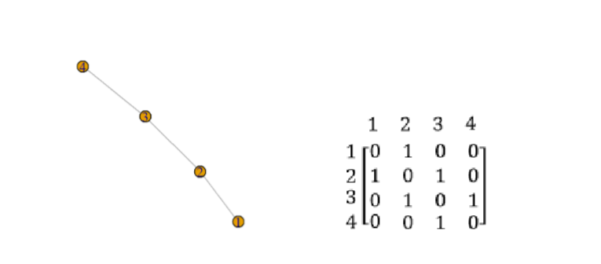

R语言中把网络转换成邻接矩阵的函数为：`as_adjacency_matrix(graph, type, attr, edges, names, sparse)`，其中，graph为要转换的网络；type只作用于无向网络，用于设置邻接矩阵是上三角、下三角矩阵还是都显示；attr若为NULL，则返回传统的邻接矩阵,若不为NULL，则给定边属性的值会被包含在邻接矩阵中；edges、names、sparse则为三个逻辑标量，分别设定是否返回连边序号、是否指定行名和列名(如果节点属性有名称的情况下)和是否创建稀疏矩阵(在矩阵中，若数值为0的元素数目远远多于非0元素的数目，并且非0元素分布没有规律时，则称该矩阵为稀疏矩阵)。

接下来新建一个网络并转换为邻接矩阵。

```r
a = data.frame(1:10,c(2,3,4,7,3,2,1,9,7,6))        # 创建一个边数据
g_a = graph_from_data_frame(a, directed = FALSE)   # 根据边数据构造网络
adj = as_adjacency_matrix(g_a, sparse = FALSE)     # 将网络转换为邻接矩阵
print(adj)                                         # 输出邻接矩阵
```

```
##    1 2 3 4 5 6 7 8 9 10
## 1  0 1 0 0 0 0 1 0 0  0
## 2  1 0 1 0 0 1 0 0 0  0
## 3  0 1 0 1 1 0 0 0 0  0
## 4  0 0 1 0 0 0 1 0 0  0
## 5  0 0 1 0 0 0 0 0 0  0
## 6  0 1 0 0 0 0 0 0 0  1
## 7  1 0 0 1 0 0 0 0 1  0
## 8  0 0 0 0 0 0 0 0 1  0
## 9  0 0 0 0 0 0 1 1 0  0
## 10 0 0 0 0 0 1 0 0 0  0
```

### 任务二: 利用邻接矩阵构建（有向、无向）网络

上个任务中，我们将网络转换成了邻接矩阵，反过来，R中也可以根据邻接矩阵创建网络，常用函数为：`graph_from_adjacency_matrix(adjmatrix, mode, weighted, diag, add.colnames, add.rownames)`.其中，adjmatrix为邻接矩阵；mode表示理解邻接矩阵的方式(如有向无向、上三角下三角等，具体可看函数help文件)；weighted说明是否构建有权网络；diag设置是否计算对角线元素；add.colnames和add.rownames分别设定是否设置列名和行名。

下面根据任务一得到的邻接矩阵来构建网络。

```r
set.seed(1)                                                    # 生成随机数种子，使每次绘制出的图相同
par(mfrow = c(1,2))                                            # 将画布分成一行两列
g3 = graph_from_adjacency_matrix(adj)                          # 构建网络，默认为有向网络
g3                                                             # 查看网络结构
```

```
## IGRAPH 95f81a8 DN-- 10 20 --
## + attr: name (v/c)
## + edges from 95f81a8 (vertex names):
##  [1] 1 ->2  1 ->7  2 ->1  2 ->3  2 ->6  3 ->2  3 ->4  3 ->5  4 ->3  4 ->7
## [11] 5 ->3  6 ->2  6 ->10 7 ->1  7 ->4  7 ->9  8 ->9  9 ->7  9 ->8  10->6
```

```r
plot(g3,edge.arrow.size = 0.3,main = '有向网络图',             # 画网络图
          vertex.label.cex = 0.7)                              # 修改节点标签大小
g4 = graph_from_adjacency_matrix(adj,mode = 'undirected')      # 构建无向网络
g4                                                             # 查看网络结构
```

```
## IGRAPH 95fc593 UN-- 10 10 --
## + attr: name (v/c)
## + edges from 95fc593 (vertex names):
##  [1] 1--2  1--7  2--3  2--6  3--4  3--5  4--7  6--10 7--9  8--9
```

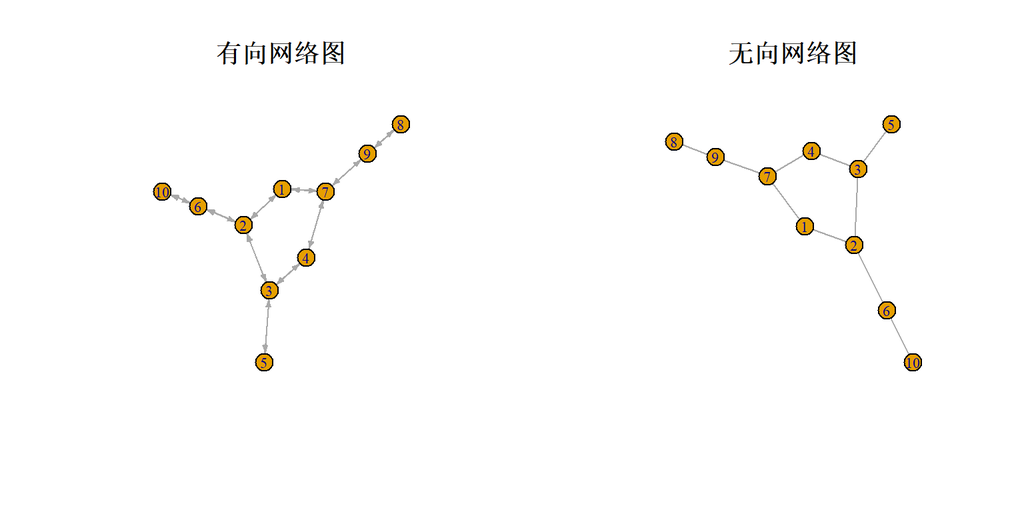

```r
plot(g4,main = '无向网络图',                                   # 画网络图
          vertex.label.cex = 0.7)                              # 修改节点标签大小
```

### 课后作业

- 作业一：对TASK2中构建的College Football网络生成邻接矩阵。
- 作业二：对结果进行适当解读。
- 选做：对TASK2中构建的权游网络生成邻接矩阵，并做适当解读。